# Variation of dietary fiber content in 282 common bean genotypes from the middle american gene pool

skammlade

31 May 2016

## Introduction

282 entries from the BeanCAP study were grown in Fort Collins, CO in 2015 to determine variation in fiber content. All entries originated from the Middle American gene pool and were further subdivided into the following races and market classes:

Number of entries by race and market class included in the study.

| Durango |  | Jalisco |  | Mesoamerican |  |
| --- | --- | --- | --- | --- | --- |
| Market Class | No. Entries | Market Class | No. Entries | Market Class | No. Entries |
| ———— | ———– | ———— | ———— | ———— | ———– |
| GN | 40 | black mottle | 1 | black | 41 |
| pinto | 91 | flor de mayo | 1 | carioca | 2 |
|  |  | pink | 22 | navy | 45 |
|  |  | red mottle | 1 | small white | 6 |
|  |  | small red | 30 | tan | 2 |
| **Totals** | **131** |  | **55** |  | **96** |

## Results: Entry Rankings

Tables below show the five entries with the greatest and five entries with the lowest values of each fiber component averaged across the two replications including standard deviation (sd), standard error (se) and confindence intervals (ci).

## – Insoluble Dietary Fiber (IDF)

Five entries with greatest IDF content.

| Entry | mktclass | race | IDF | sd | se | ci |
| --- | --- | --- | --- | --- | --- | --- |
| PR0443-151 | black | mesoamerican | 16.91 | 1.55 | 1.09 | 13.89 |
| CDC Pinnacle | pinto | durango | 16.73 | 2.76 | 1.95 | 24.80 |
| CDC Jet | black | mesoamerican | 16.71 | 1.32 | 0.94 | 11.90 |
| TARS-VCI-4B | pinto | durango | 16.46 | 3.43 | 2.42 | 30.79 |
| TARS09-RR007 | small red | jalisco | 16.42 | 0.51 | 0.36 | 4.59 |

Five entries with lowest IDF content.

| Entry | mktclass | race | IDF | sd | se | ci |
| --- | --- | --- | --- | --- | --- | --- |
| BelMiNeb-RMR-4 | navy | mesoamerican | 12.34 | 0.11 | 0.08 | 0.97 |
| BelMiNeb-RMR-8 | navy | mesoamerican | 12.05 | 0.38 | 0.27 | 3.43 |
| BelMiNeb-RMR-7 | navy | mesoamerican | 11.77 | 0.31 | 0.22 | 2.77 |
| BelMiNeb-RMR-3 | GN | durango | 11.75 | 0.22 | 0.15 | 1.97 |
| AC Pintoba | pinto | durango | 11.44 | 0.19 | 0.13 | 1.70 |

## – Soluble Dietary Fiber (SDF)

Five entries with greatest SDF content.

| Entry | mktclass | race | SDF | sd | se | ci |
| --- | --- | --- | --- | --- | --- | --- |
| Voyager | navy | mesoamerican | 10.29 | 0.12 | 0.08 | 1.03 |
| SR7-3 | small red | jalisco | 9.83 | 0.83 | 0.59 | 7.48 |
| NW-63 | small red | jalisco | 9.81 | 0.43 | 0.30 | 3.84 |
| IP08-2 | pinto | durango | 9.48 | 0.76 | 0.53 | 6.79 |
| BelMiNeb 2 | GN | durango | 9.45 | 0.05 | 0.03 | 0.42 |

Five entries with lowest SDF content.

| Entry | mktclass | race | SDF | sd | se | ci |
| --- | --- | --- | --- | --- | --- | --- |
| ABCP-15 | pinto | durango | 5.76 | 0.56 | 0.39 | 5.00 |
| Quincy | pinto | durango | 5.53 | 0.22 | 0.16 | 2.00 |
| Centa Pupil | small red | jalisco | 5.34 | 0.52 | 0.37 | 4.69 |
| TARS-VCI-4B | pinto | durango | 5.16 | 1.32 | 0.93 | 11.84 |
| I9365-5 | pink | jalisco | 5.09 | 1.57 | 1.11 | 14.13 |

## – Raffinose (Raff)

Five entries with greatest raffinose content.

| Entry | mktclass | race | Raff | sd | se | ci |
| --- | --- | --- | --- | --- | --- | --- |
| NE1-09-20 | GN | durango | 0.92 | 0.06 | 0.04 | 0.50 |
| CDC Crocus | GN | durango | 0.85 | 0.05 | 0.04 | 0.47 |
| I9365-31 | black | mesoamerican | 0.85 | 0.25 | 0.18 | 2.24 |
| A-55 | black | mesoamerican | 0.79 | 0.06 | 0.04 | 0.56 |
| NE1-09-9 | GN | durango | 0.79 | 0.10 | 0.07 | 0.86 |

Five entries with lowest raffinose content.

| Entry | mktclass | race | Raff | sd | se | ci |
| --- | --- | --- | --- | --- | --- | --- |
| Sawtooth | GN | durango | 0.30 | 0.11 | 0.08 | 0.96 |
| USRM-20 | small red | jalisco | 0.30 | 0.03 | 0.02 | 0.28 |
| Bill Z | pinto | durango | 0.28 | 0.01 | 0.01 | 0.13 |
| Ind. Jamaica Red | red mottle | jalisco | 0.28 | 0.07 | 0.05 | 0.60 |
| Apache | pinto | durango | 0.27 | 0.01 | 0.01 | 0.07 |

## – Stachyose (Stach)

Five entries with greatest stachyose content.

| Entry | mktclass | race | Stach | sd | se | ci |
| --- | --- | --- | --- | --- | --- | --- |
| ND021717 | black | mesoamerican | 5.16 | 1.86 | 1.31 | 16.69 |
| Centa Pupil | small red | jalisco | 4.90 | 0.26 | 0.18 | 2.29 |
| Ind. Jamaica Red | red mottle | jalisco | 4.89 | 0.43 | 0.31 | 3.90 |
| GN Star | GN | durango | 4.78 | 0.17 | 0.12 | 1.57 |
| Inta Precoz | small red | jalisco | 4.70 | 0.28 | 0.20 | 2.48 |

Five entries with lowest stachyose content.

| Entry | mktclass | race | Stach | sd | se | ci |
| --- | --- | --- | --- | --- | --- | --- |
| ND040494-4 | pinto | durango | 3.10 | 0.24 | 0.17 | 2.11 |
| NE1-09-9 | GN | durango | 3.07 | 0.32 | 0.23 | 2.86 |
| NE1-09-20 | GN | durango | 3.03 | 0.08 | 0.05 | 0.69 |
| T9905 | navy | mesoamerican | 3.00 | 0.10 | 0.07 | 0.93 |
| F07-449-9-3 | small red | jalisco | 2.99 | 0.18 | 0.13 | 1.61 |

## – Verbascose (Verb)

Five entries with greatest verbascose content.

| Entry | mktclass | race | Verb | sd | se | ci |
| --- | --- | --- | --- | --- | --- | --- |
| Ind. Jamaica Red | red mottle | jalisco | 0.233 | 0.031 | 0.022 | 0.281 |
| Pink Floyd | pink | jalisco | 0.233 | 0.002 | 0.001 | 0.017 |
| ROG 312 | pink | jalisco | 0.229 | 0.024 | 0.017 | 0.216 |
| ABC-Weihing | GN | durango | 0.201 | 0.016 | 0.011 | 0.143 |
| GN Star | GN | durango | 0.201 | 0.002 | 0.002 | 0.020 |

Five entries with lowest verbascose content.

| Entry | mktclass | race | Verb | sd | se | ci |
| --- | --- | --- | --- | --- | --- | --- |
| NE1-09-22 | GN | durango | 0.038 | 0.001 | 0.001 | 0.012 |
| T9905 | navy | mesoamerican | 0.037 | 0.011 | 0.008 | 0.096 |
| A-55 | black | mesoamerican | 0.036 | 0.035 | 0.025 | 0.317 |
| GN9-4 | GN | durango | 0.033 | 0.032 | 0.022 | 0.284 |
| McHale | navy | mesoamerican | 0.021 | 0.006 | 0.004 | 0.050 |

## – Total Oligosachharides (TOligos)

Five entries with greatest total oligosaccharide (= Raff + Stach + Verb) content.

| Entry | mktclass | race | TOligos | sd | se | ci |
| --- | --- | --- | --- | --- | --- | --- |
| ND021717 | black | mesoamerican | 5.98 | 2.22 | 1.57 | 19.92 |
| Centa Pupil | small red | jalisco | 5.45 | 0.18 | 0.13 | 1.62 |
| Ind. Jamaica Red | red mottle | jalisco | 5.40 | 0.47 | 0.33 | 4.22 |
| GN Star | GN | durango | 5.39 | 0.23 | 0.16 | 2.04 |
| Inta Precoz | small red | jalisco | 5.32 | 0.25 | 0.18 | 2.24 |

Five entries with lowest total oligosaccharide (= Raff + Stach + Verb) content.

| Entry | mktclass | race | TOligos | sd | se | ci |
| --- | --- | --- | --- | --- | --- | --- |
| Mariah | pinto | durango | 3.60 | 0.30 | 0.21 | 2.67 |
| NE1-09-19 | GN | durango | 3.57 | 0.08 | 0.06 | 0.71 |
| ND040494-4 | pinto | durango | 3.55 | 0.14 | 0.10 | 1.24 |
| T9905 | navy | mesoamerican | 3.53 | 0.12 | 0.09 | 1.08 |
| F07-449-9-3 | small red | jalisco | 3.50 | 0.06 | 0.04 | 0.57 |

## – Total Dietary Fiber (TDF)

Five entries with greatest total DF (= IDF + SDF + Raff + Stach + Verb) content.

| Entry | mktclass | race | TDF | sd | se | ci |
| --- | --- | --- | --- | --- | --- | --- |
| PR0443-151 | black | mesoamerican | 30.23 | 1.22 | 0.87 | 11.00 |
| IP08-2 | pinto | durango | 30.06 | 0.15 | 0.11 | 1.39 |
| ND021717 | black | mesoamerican | 29.78 | 0.83 | 0.59 | 7.48 |
| AC Resolute | GN | durango | 29.45 | 1.57 | 1.11 | 14.08 |
| Max | pinto | durango | 28.59 | 0.81 | 0.57 | 7.26 |

Five entries with lowest total DF (= IDF + SDF + Raff + Stach + Verb) content.

| Entry | mktclass | race | TDF | sd | se | ci |
| --- | --- | --- | --- | --- | --- | --- |
| T9905 | navy | mesoamerican | 23.59 | 0.93 | 0.66 | 8.39 |
| Norstar | navy | mesoamerican | 23.43 | 0.31 | 0.22 | 2.77 |
| BelMiNeb-RMR-7 | navy | mesoamerican | 23.36 | 0.12 | 0.08 | 1.05 |
| Topaz | pinto | durango | 23.18 | 0.00 | 0.00 | 0.02 |
| AC Pintoba | pinto | durango | 22.82 | 0.80 | 0.57 | 7.19 |

## Results: Marketclass

## – Boxplots

Figures below depict fiber content by market class.

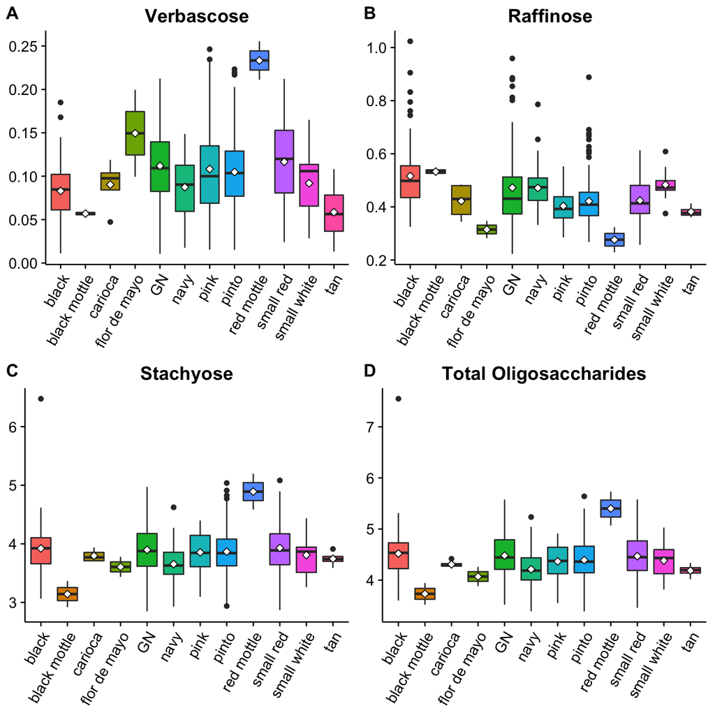

| Marketclass | Verbascose | Raffinose | Stachyose | Total Oligosaccharides |
| --- | --- | --- | --- | --- |
| black | 0.083 a | 0.516 c | 3.92 b | 4.52 bc |
| black mottle | 0.057 ab | 0.533 bc | 3.14 ab | 3.73 ab |
| carioca | 0.09 ab | 0.422 bc | 3.8 ab | 4.31 abc |
| flor de mayo | 0.149 abd | 0.315 bc | 3.61 ab | 4.07 abc |
| GN | 0.112 b | 0.472 ac | 3.9 b | 4.48 bc |
| navy | 0.087 ac | 0.471 ac | 3.65 a | 4.21 a |
| pink | 0.108 bc | 0.403 b | 3.86 ab | 4.37 ab |
| pinto | 0.105 b | 0.421 b | 3.87 b | 4.39 b |
| red mottle | 0.233 d | 0.276 ab | 4.89 c | 5.4 c |
| small red | 0.117 b | 0.424 ab | 3.93 b | 4.47 bc |
| small white | 0.092 ab | 0.483 bc | 3.81 ab | 4.38 abc |
| tan | 0.059 ab | 0.382 bc | 3.75 ab | 4.19 ab |

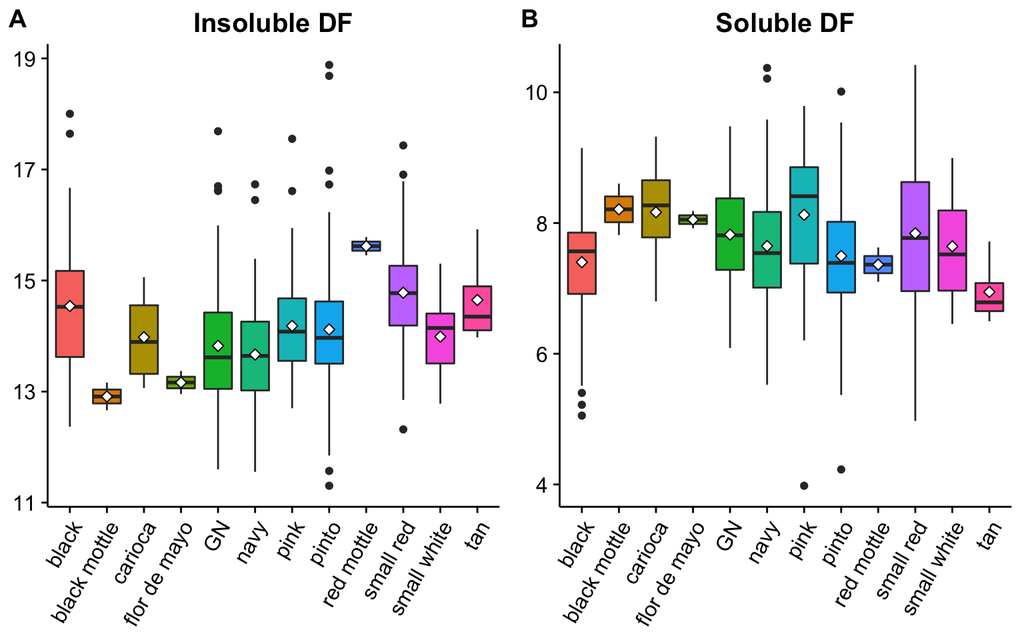

| Marketclass | Insoluble DF | Soluble DF |
| --- | --- | --- |
| black | 14.541 cd | 7.401 b |
| black mottle | 12.911 abc | 8.21 ab |
| carioca | 13.978 abc | 8.166 ab |
| flor de mayo | 13.163 abc | 8.052 ab |
| GN | 13.823 ab | 7.824 ab |
| navy | 13.667 a | 7.648 ab |
| pink | 14.182 abc | 8.126 a |
| pinto | 14.119 bd | 7.496 b |
| red mottle | 15.619 abc | 7.364 ab |
| small red | 14.78 c | 7.843 ab |
| small white | 13.99 abc | 7.643 ab |
| tan | 14.649 abc | 6.947 ab |

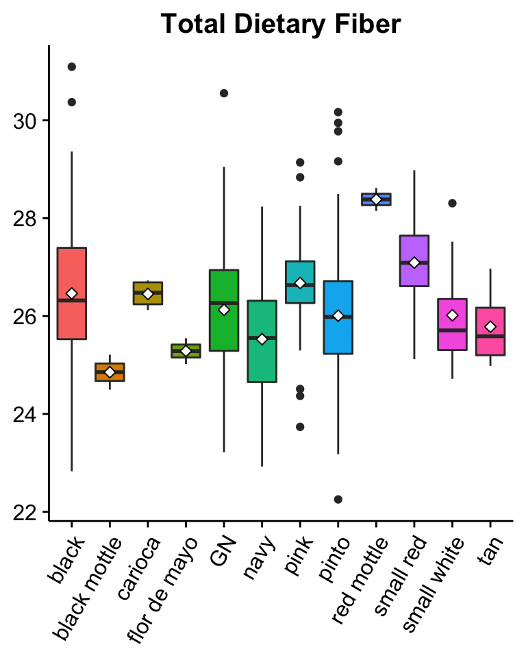

Total Dietary Fiber content in 282 common bean genotypes by marketclass

| Marketclass | Total DF |
| --- | --- |
| black | 26.462 bc |
| black mottle | 24.853 abc |
| carioca | 26.452 abc |
| flor de mayo | 25.286 abc |
| GN | 26.128 cd |
| navy | 25.528 a |
| pink | 26.675 bd |
| pinto | 26.007 ac |
| red mottle | 28.383 bc |
| small red | 27.092 b |
| small white | 26.017 abc |
| tan | 25.782 abc |

## Results: Race

## – Boxplots

Figures below depict fiber content by race.

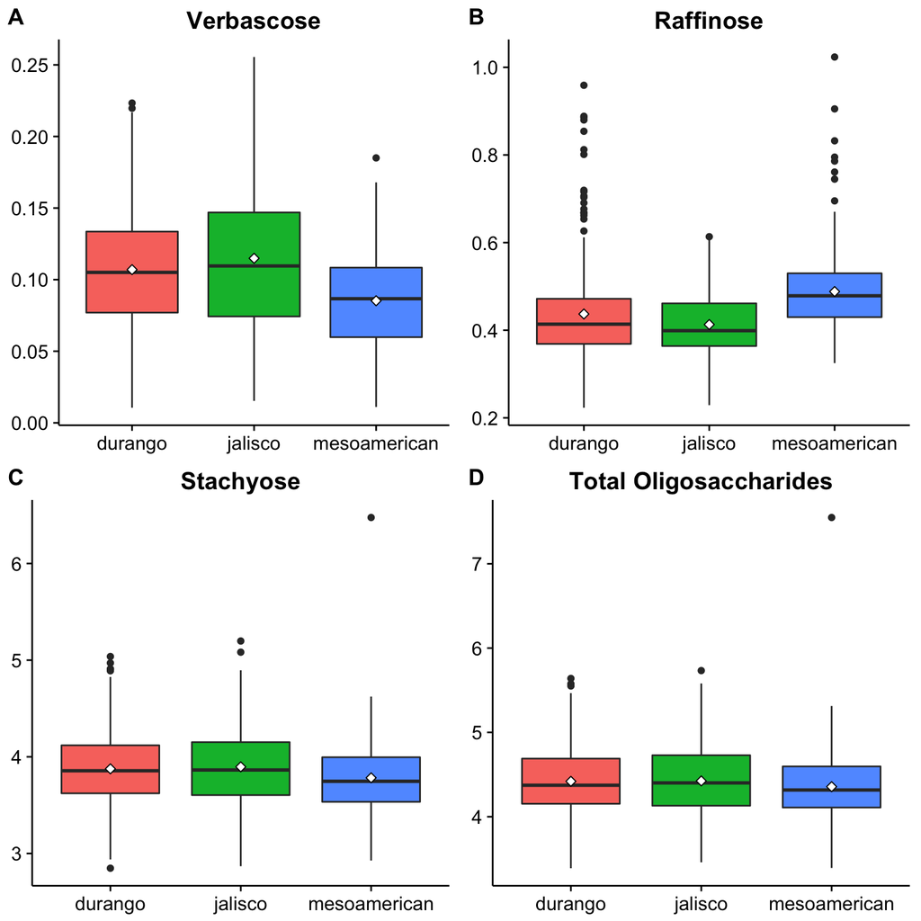

| Race | Verbascose | Raffinose | Stachyose | Total Oligosaccharides |
| --- | --- | --- | --- | --- |
| Durango | 0.107 b | 0.437 a | 3.88 b | 4.42 a |
| Jalisco | 0.115 b | 0.413 a | 3.9 ab | 4.42 a |
| Mesoamerican | 0.085 a | 0.488 b | 3.78 a | 4.36 a |

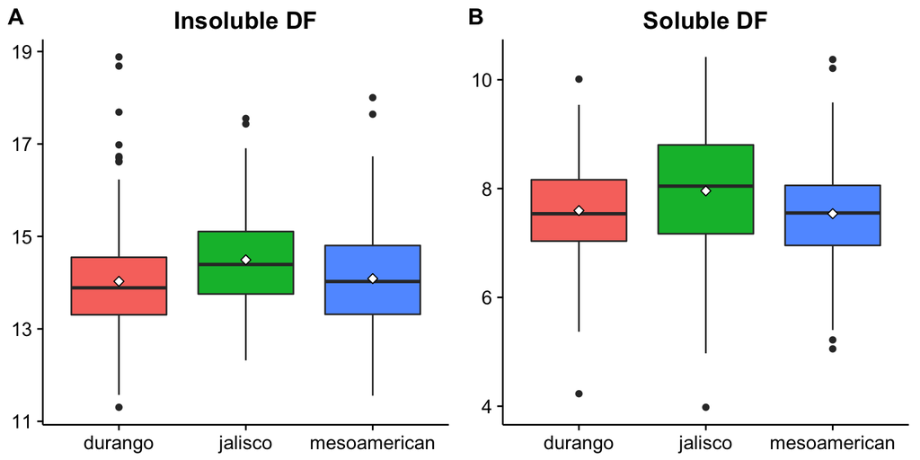

| Race | Insoluble DF | Soluble DF |
| --- | --- | --- |
| Durango | 14.028 a | 7.596 a |
| Jalisco | 14.493 b | 7.958 b |
| Mesoamerican | 14.087 a | 7.538 a |

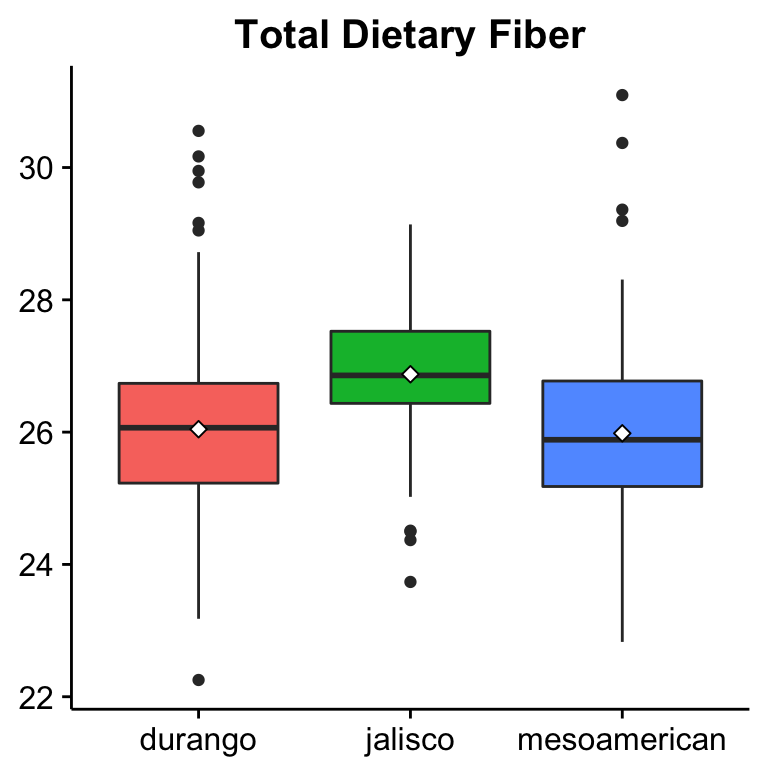

Total Dietary Fiber content in 282 common bean genotypes by race

| Race | Total DF |
| --- | --- |
| Durango | 26.044 a |
| Jalisco | 26.875 b |
| Mesoamerican | 25.982 a |

## Statistical Methods

Statistical analyses, figures, tables, and reporting was completed using RStudio Version 0.98.1062.

## – *Assumptions of Normality and Homogeneity of Variance*

Insoluble fiber, soluble fiber, raffanose, stachyose, and verbascose data were concluded to meet the assumptions of normality after plotting histograms, qqplots, and residuals versus predicted values as well as conducting Shapiro-Wilk and one-sample Kolmogorov-Smirnov normality tests.

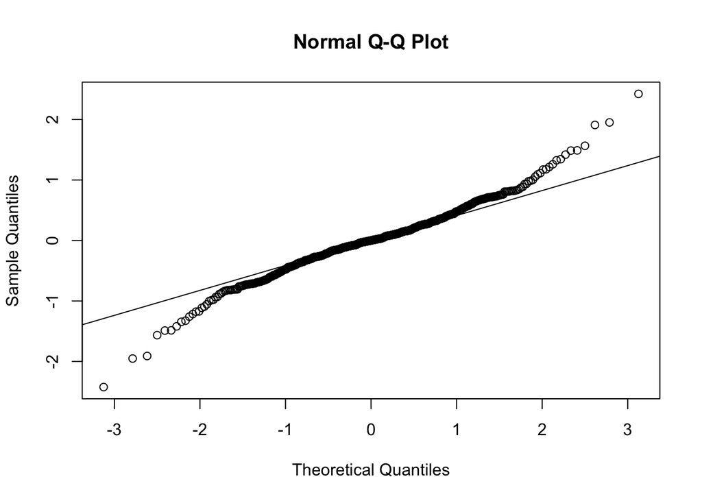

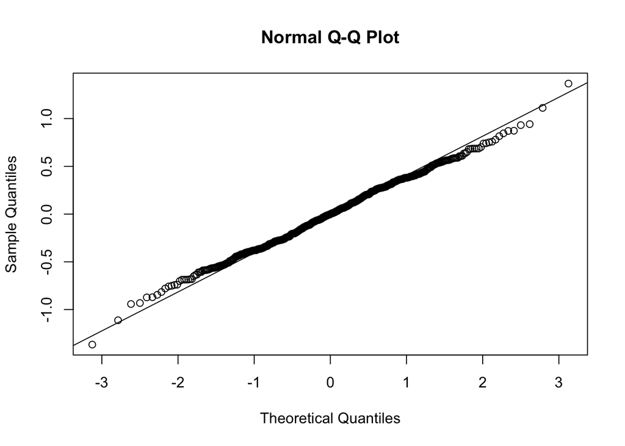

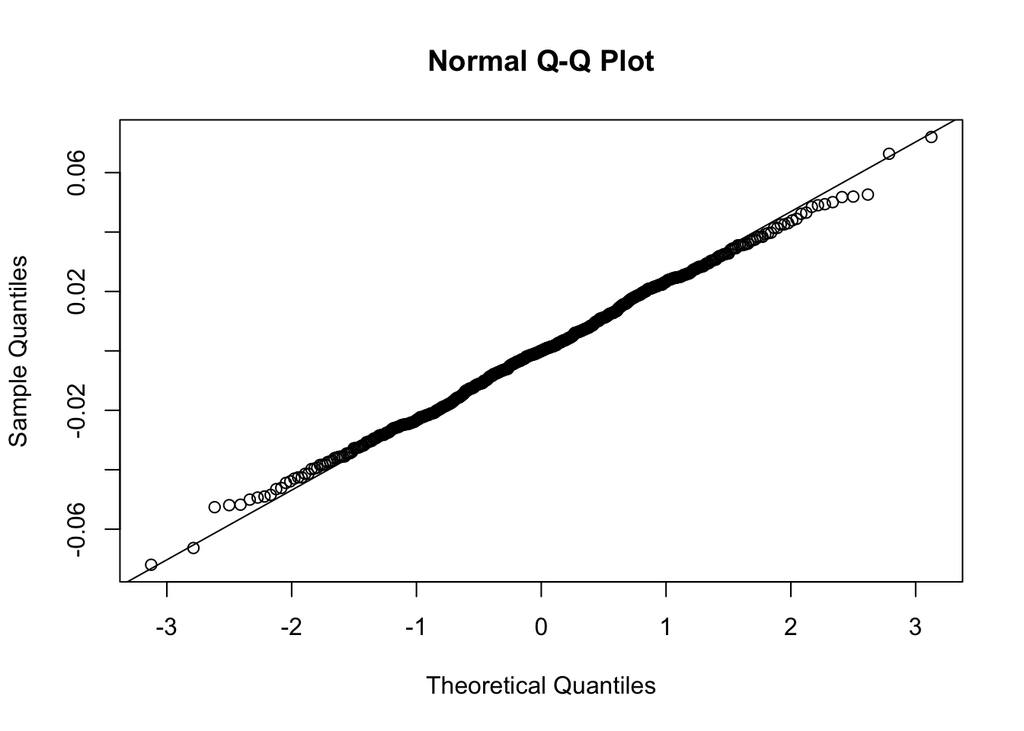

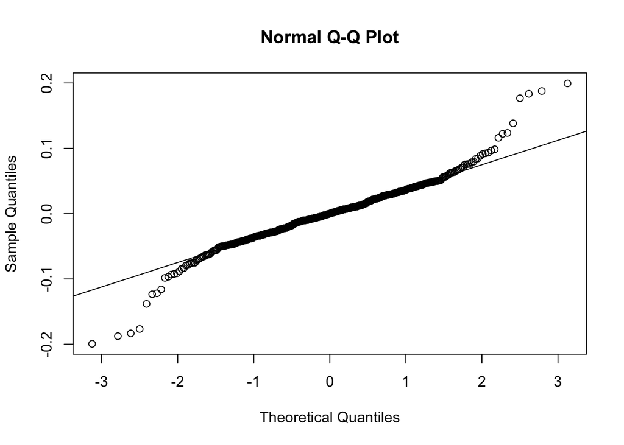

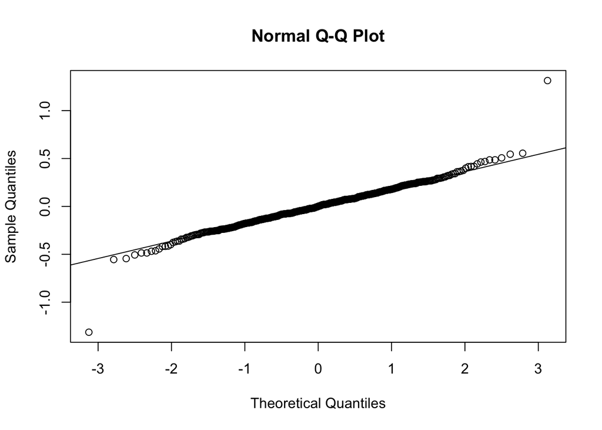

## – *One-way ANOVA*

One-way analysis of variance was conducted to determine the effect of 1)market class and 2) race on fiber components of the 282 entries using the aov function.

#### *1) Market class*

One-way ANOVA table testing differences in insoluble DF between market classes.

|  | Df | Sum Sq | Mean Sq | F value | Pr(>F) |
| --- | --- | --- | --- | --- | --- |
| mktclass | 11 | 76.7617 | 6.9783 | 6.0667 | 0 |
| Residuals | 552 | 634.9496 | 1.1503 | NA | NA |

One-way ANOVA table testing differences in soluble DF between market classes.

|  | Df | Sum Sq | Mean Sq | F value | Pr(>F) |
| --- | --- | --- | --- | --- | --- |
| mktclass | 11 | 28.1329 | 2.5575 | 2.99 | 7e-04 |
| Residuals | 552 | 472.1533 | 0.8554 | NA | NA |

One-way ANOVA table testing differences in verbascose between market classes.

|  | Df | Sum Sq | Mean Sq | F value | Pr(>F) |
| --- | --- | --- | --- | --- | --- |
| mktclass | 11 | 0.1246 | 0.0113 | 7.0095 | 0 |
| Residuals | 552 | 0.8920 | 0.0016 | NA | NA |

One-way ANOVA table testing differences in raffanose DF between market classes.

|  | Df | Sum Sq | Mean Sq | F value | Pr(>F) |
| --- | --- | --- | --- | --- | --- |
| mktclass | 11 | 0.8693 | 0.0790 | 8.0515 | 0 |
| Residuals | 552 | 5.4182 | 0.0098 | NA | NA |

One-way ANOVA table testing differences in stachyose DF between market classes.

|  | Df | Sum Sq | Mean Sq | F value | Pr(>F) |
| --- | --- | --- | --- | --- | --- |
| mktclass | 11 | 7.8272 | 0.7116 | 4.5727 | 0 |
| Residuals | 552 | 85.8973 | 0.1556 | NA | NA |

One-way ANOVA table testing differences in total oligosaccharides DF between market classes.

|  | Df | Sum Sq | Mean Sq | F value | Pr(>F) |
| --- | --- | --- | --- | --- | --- |
| mktclass | 11 | 8.5502 | 0.7773 | 4.3318 | 0 |
| Residuals | 552 | 99.0505 | 0.1794 | NA | NA |

One-way ANOVA table testing differences in total DF between market classes.

|  | Df | Sum Sq | Mean Sq | F value | Pr(>F) |
| --- | --- | --- | --- | --- | --- |
| mktclass | 11 | 127.1475 | 11.5589 | 8.0004 | 0 |
| Residuals | 552 | 797.5236 | 1.4448 | NA | NA |

#### *2) Race*

One-way ANOVA table testing differences in insoluble DF between races.

|  | Df | Sum Sq | Mean Sq | F value | Pr(>F) |
| --- | --- | --- | --- | --- | --- |
| race | 2 | 17.4862 | 8.7431 | 7.0653 | 9e-04 |
| Residuals | 561 | 694.2251 | 1.2375 | NA | NA |

One-way ANOVA table testing differences in soluble DF between races.

|  | Df | Sum Sq | Mean Sq | F value | Pr(>F) |
| --- | --- | --- | --- | --- | --- |
| race | 2 | 13.5696 | 6.7848 | 7.8203 | 4e-04 |
| Residuals | 561 | 486.7165 | 0.8676 | NA | NA |

One-way ANOVA table testing differences in verbascose between races.

|  | Df | Sum Sq | Mean Sq | F value | Pr(>F) |
| --- | --- | --- | --- | --- | --- |
| race | 2 | 0.0782 | 0.0391 | 23.3805 | 0 |
| Residuals | 561 | 0.9384 | 0.0017 | NA | NA |

One-way ANOVA table testing differences in raffanose DF between races.

|  | Df | Sum Sq | Mean Sq | F value | Pr(>F) |
| --- | --- | --- | --- | --- | --- |
| race | 2 | 0.4754 | 0.2377 | 22.9451 | 0 |
| Residuals | 561 | 5.8121 | 0.0104 | NA | NA |

One-way ANOVA table testing differences in stachyose DF between races.

|  | Df | Sum Sq | Mean Sq | F value | Pr(>F) |
| --- | --- | --- | --- | --- | --- |
| race | 2 | 1.2766 | 0.6383 | 3.8734 | 0.0213 |
| Residuals | 561 | 92.4478 | 0.1648 | NA | NA |

One-way ANOVA table testing differences in total oligosaccharides DF between races.

|  | Df | Sum Sq | Mean Sq | F value | Pr(>F) |
| --- | --- | --- | --- | --- | --- |
| race | 2 | 0.5340 | 0.2670 | 1.3989 | 0.2477 |
| Residuals | 561 | 107.0668 | 0.1908 | NA | NA |

One-way ANOVA table testing differences in total DF between races.

|  | Df | Sum Sq | Mean Sq | F value | Pr(>F) |
| --- | --- | --- | --- | --- | --- |
| race | 2 | 65.4603 | 32.7301 | 21.3703 | 0 |
| Residuals | 561 | 859.2108 | 1.5316 | NA | NA |

## – *Pairwise Comparisons*

Tukey adjusted pairwise comparisons were made between each market class and each race for each fiber component using the TukeyHSD funcion.

```r
OneWayFit <- aov(IDF~race, data=fiber)
TukeyHSD(OneWayFit)

library(multcomp)
PairComps <- glht(OneWayFit, linfct=mcp(race="Tukey"))
summary(PairComps)
cld(PairComps)
```

[output not shown]